# FurkanGundogan_pro

#### 5.) Apply PCA to perform dimensionality reduction on the dataset within 2-dimensional (feature) space.

```
I need to scale dataset before apply PCA.
Firstly, i converted Genre and Director features by LabelEncoder.
After that i did scale some of my numeric features: Genre, Director, Year, Votes, Revenue.
Then i dropped Title column, because its unique and i did not need to use this feature.
```

```python
from sklearn.preprocessing import LabelEncoder

le_genre = LabelEncoder()
le_genre.fit(imdb["Genre"])
encoded_genre_training = le_genre.transform(imdb["Genre"])
imdb["Genre"] = encoded_genre_training


le_director = LabelEncoder()
le_director.fit(imdb["Director"])
encoded_director_training = le_director.transform(imdb["Director"])
imdb["Director"] = encoded_director_training


from sklearn.preprocessing import StandardScaler

scaler = StandardScaler()

genre_scaled = np.array(imdb["Genre"]).reshape(-1, 1)
director_scaled = np.array(imdb["Director"]).reshape(-1, 1)
year_scaled = np.array(imdb["Year"]).reshape(-1, 1)
runtime_scaled = np.array(imdb["Runtime"]).reshape(-1, 1)
votes_scaled = np.array(imdb["Votes"]).reshape(-1, 1)
revenue_scaled = np.array(imdb["Revenue"]).reshape(-1, 1)

copy_imdb = imdb.copy()
copy_imdb["Genre"] = scaler.fit_transform(genre_scaled)
copy_imdb["Director"] = scaler.fit_transform(director_scaled)
copy_imdb["Year"] = scaler.fit_transform(year_scaled)
copy_imdb["Runtime"] = scaler.fit_transform(runtime_scaled)
copy_imdb["Votes"] = scaler.fit_transform(votes_scaled)
copy_imdb["Revenue"] = scaler.fit_transform(revenue_scaled)
```

```python
copy_imdb.drop(labels=["Title"], axis=1,inplace=True)
```

```python
copy_imdb.head()
```

|  | Genre | Director | Year | Runtime | Rating | Votes | Revenue | Metascore |
| --- | --- | --- | --- | --- | --- | --- | --- | --- |
| 0 | -1.459278 | -0.335620 | 0.379795 | 0.416350 | 8.1 | 3.112690 | 2.623377 | 81.0 |
| 1 | -0.258280 | 1.027352 | -0.244355 | 0.575911 | 7.0 | 1.674960 | 0.494284 | 65.0 |
| 2 | 1.526988 | 0.343173 | 1.003945 | 0.203601 | 7.3 | -0.064676 | 0.614405 | 62.0 |
| 3 | -0.144672 | -1.197578 | 1.003945 | -0.275084 | 7.2 | -0.579129 | 1.976315 | 59.0 |
| 4 | -1.524197 | -1.030574 | 1.003945 | 0.522724 | 6.2 | 1.186839 | 2.539829 | 40.0 |

```
My dataset has 8 dimensions. I will reduce it to 2 with applying PCA.
Then i will visualize with 'Rating' feature, to see distrubuton of 'being greater or smaller than 7.5'
```

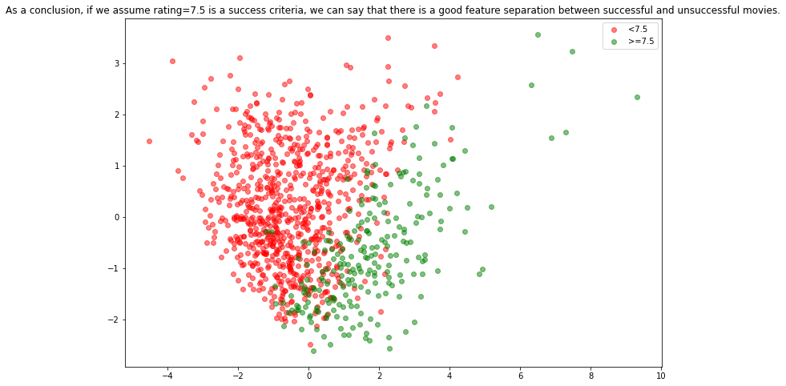

```python
from sklearn.preprocessing import StandardScaler
#                                         4=rating column
X, y = copy_imdb.iloc[:,:], copy_imdb.iloc[:,4]

X_pca1 = X.copy()
#todo: scale the input data
X_pca1=StandardScaler().fit_transform(X_pca1)

from sklearn.decomposition import PCA
pca=PCA(n_components=2)
X_redu1=pca.fit_transform(X_pca1)

#reduced data
low = X_redu1[y < 7.5]
high = X_redu1[y >= 7.5]
comp =[0,1]

fig = plt.figure(figsize = (12,8))
plt.scatter(low[:,0].reshape(1,-1), low[:,1].reshape(1,-1), c = 'red', label = '<7.5', alpha = 0.5)
plt.scatter(high[:,0].reshape(1,-1), high[:,1].reshape(1,-1), c = 'green', label = '>=7.5', alpha = 0.5)
plt.legend(['<7.5', '>=7.5'])

myconclusion="As a conclusion, if we assume rating=7.5 is a success criteria, we can say that there is a good feature separation between successful and unsuccessful movies."
plt.title(myconclusion)
plt.show()
```

## Classification

### KNN (K-Nearest Neighbors) Algorithm

```
K value means the number of neighbors to look at. When a value comes, the distance between the incoming value is
calculated by taking the nearest K element.
After the distance is calculated, the value is assigned to the appropriate class.
```

### Implementation

#### I wanted to do a classification analysis for the movies in my dataset based on whether they bring high or low profits.

```python
imdb2=imdb.copy()
imdb2
```

|  | Title | Genre | Director | Year | Runtime | Rating | Votes | Revenue | Metascore |
| --- | --- | --- | --- | --- | --- | --- | --- | --- | --- |
| 0 | Guardians of the Galaxy | 11 | 265 | 2014 | 121 | 8.1 | 757074 | 333.130 | 81.0 |
| 1 | Prometheus | 85 | 518 | 2012 | 124 | 7.0 | 485820 | 126.460 | 65.0 |
| 2 | Split | 195 | 391 | 2016 | 117 | 7.3 | 157606 | 138.120 | 62.0 |
| 3 | Sing | 92 | 105 | 2016 | 108 | 7.2 | 60545 | 270.320 | 59.0 |
| 4 | Suicide Squad | 7 | 136 | 2016 | 123 | 6.2 | 393727 | 325.020 | 40.0 |
| ... | ... | ... | ... | ... | ... | ... | ... | ... | ... |
| 995 | Secret in Their Eyes | 144 | 69 | 2015 | 111 | 6.2 | 27585 | 47.985 | 45.0 |
| 996 | Hostel: Part II | 190 | 176 | 2007 | 94 | 5.5 | 73152 | 17.540 | 46.0 |
| 997 | Step Up 2: The Streets | 170 | 324 | 2008 | 98 | 6.2 | 70699 | 58.010 | 50.0 |
| 998 | Search Party | 61 | 549 | 2014 | 93 | 5.6 | 4881 | 47.985 | 22.0 |
| 999 | Nine Lives | 121 | 59 | 2016 | 87 | 5.3 | 12435 | 19.640 | 11.0 |

1000 rows × 9 columns

#### - I took off Title, Year, Runtime and columns.

#### - Beacuse i think they won't be very effective to determine film profit classification.

#### - I also took of Metascore because Rating column is enough.

```python
imdb2.drop(labels=["Title","Year","Runtime","Metascore"], axis=1,inplace=True)
```

#### I changed Revenue column values to ones and zeros according to their revenue value

#### High profit: >= 200 mn

#### Low profit: < 200 mn

```python
imdb2.loc[imdb2.Revenue < 200, 'Revenue'] = 0
imdb2.loc[imdb2.Revenue >= 200, 'Revenue'] = 1
```

```python
imdb2
```

|  | Genre | Director | Rating | Votes | Revenue |
| --- | --- | --- | --- | --- | --- |
| 0 | 11 | 265 | 8.1 | 757074 | 1.0 |
| 1 | 85 | 518 | 7.0 | 485820 | 0.0 |
| 2 | 195 | 391 | 7.3 | 157606 | 0.0 |
| 3 | 92 | 105 | 7.2 | 60545 | 1.0 |
| 4 | 7 | 136 | 6.2 | 393727 | 1.0 |
| ... | ... | ... | ... | ... | ... |
| 995 | 144 | 69 | 6.2 | 27585 | 0.0 |
| 996 | 190 | 176 | 5.5 | 73152 | 0.0 |
| 997 | 170 | 324 | 6.2 | 70699 | 0.0 |
| 998 | 61 | 549 | 5.6 | 4881 | 0.0 |
| 999 | 121 | 59 | 5.3 | 12435 | 0.0 |

1000 rows × 5 columns

#### I divided dependent and independent variables into different arrays

#### Independent variables; Genre, Director, Rating and Votes

#### Target dependent variable: Revenue

```python
my_x = imdb2.iloc[:, [0,1,2,3]].values
```

```python
my_y = imdb2.iloc[:, 4].values
```

#### I divided the 1000-element dataset into two parts as train and test.

#### - 750 data to train

#### - 250 data to test

```python
from sklearn.model_selection import train_test_split
X_train, X_test, y_train, y_test = train_test_split(my_x, my_y, test_size = 0.25, random_state = 0)
```

#### Then data is normalized with StandardScaler to get more successful results.

```python
from sklearn.preprocessing import StandardScaler
sc_X = StandardScaler()
X_train = sc_X.fit_transform(X_train)
X_test = sc_X.transform(X_test)
```

Scaled train dataset

```python
X_train
```

```
array([[-1.464874  ,  0.36312237, -0.01351204,  0.93753282],
       [-0.56540909,  1.2730897 , -0.42296793, -0.1815421 ],
       [-1.464874  , -1.16802026,  0.29357987,  1.55173568],
       ...,
       [-0.61447081,  1.30033423, -0.5253319 , -0.5155196 ],
       [-0.54905518,  0.61922096, -0.11587602, -0.29552619],
       [ 1.23352072, -0.68306761,  1.01012767,  0.41001941]])
```

### Trainings and Predictions

#### Using the KNN algorithm from K=1 to 10, we trained the model with 750 training data and tested with 250 data.

#### The Euclidean function is used in distance calculation. As an alternative Manhattan, Minkowski and Hamming can also be used.

#### For every k value, I put every accuracy score in a list.

#### K=1 has highest accuracy, K=3 has second highest.

```python
from sklearn.metrics import confusion_matrix
from sklearn.metrics import accuracy_score
from sklearn.model_selection import cross_val_score
from sklearn.neighbors import KNeighborsClassifier
m=11
acc_list=np.zeros((m-1))
cm=[]
for i in range (1,m):
    classifier = KNeighborsClassifier(n_neighbors=i, metric='euclidean', p = 2)
    classifier.fit(X_train, y_train)
    y_pred = classifier.predict(X_test)
    score=round(accuracy_score(y_test,y_pred),3)
    acc_list[i-1]=score
acc_list
```

```
array([0.92 , 0.904, 0.908, 0.892, 0.896, 0.888, 0.892, 0.884, 0.892,
       0.88 ])
```

### Analyzing k=1

##### Training

```python
# knn k=1
from sklearn.neighbors import KNeighborsClassifier
classifier = KNeighborsClassifier(n_neighbors=1, metric='euclidean', p = 2)
classifier.fit(X_train, y_train)
```

```
KNeighborsClassifier(metric='euclidean', n_neighbors=1)
```

##### Prediction

```python
y_pred = classifier.predict(X_test)
```

##### Confusion Matrix

```python
from sklearn.metrics import confusion_matrix
cm = confusion_matrix(y_test, y_pred)
cm
```

```
array([[212,   7],
       [ 13,  18]], dtype=int64)
```

##### Confusion Matrix Heatmap

```
Accuracy: 0.92
```

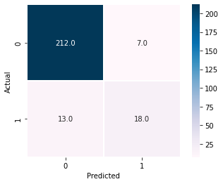

```python
from sklearn.metrics import accuracy_score
from sklearn.model_selection import cross_val_score
score=round(accuracy_score(y_test,y_pred),3)
print("Accuracy:",score)
cm1=cm
sns.heatmap(cm1,annot=True,fmt=".1f",linewidths=.2,square=True,cmap="PuBu")
plt.xlabel("Predicted");
plt.ylabel("Actual");
plt.show()
```

##### Classification Report

```python
from sklearn.metrics import classification_report
print(classification_report(y_test,y_pred))
```

```
              precision    recall  f1-score   support

         0.0       0.94      0.97      0.95       219
         1.0       0.72      0.58      0.64        31

    accuracy                           0.92       250
   macro avg       0.83      0.77      0.80       250
weighted avg       0.91      0.92      0.92       250
```

### Result k=1

[output not shown]

### Analyzing k=3

##### Training

```python
# knn k=3
from sklearn.neighbors import KNeighborsClassifier
classifier = KNeighborsClassifier(n_neighbors=3, metric='euclidean', p = 2)
classifier.fit(X_train, y_train)
```

```
KNeighborsClassifier(metric='euclidean', n_neighbors=3)
```

##### Prediction and Confusion Matrix

```python
y_pred = classifier.predict(X_test)
from sklearn.metrics import confusion_matrix
cm = confusion_matrix(y_test, y_pred)
cm
```

```
array([[214,   5],
       [ 18,  13]], dtype=int64)
```

##### Confusion Matrix Heatmap

```
Accuracy: 0.908
```

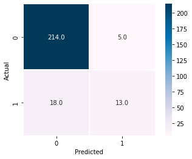

```python
from sklearn.metrics import accuracy_score
from sklearn.model_selection import cross_val_score
score=round(accuracy_score(y_test,y_pred),3)
print("Accuracy:",score)
cm1=cm
sns.heatmap(cm1,annot=True,fmt=".1f",linewidths=.2,square=True,cmap="PuBu")
plt.xlabel("Predicted");
plt.ylabel("Actual");
plt.show()
```

##### Classification Report

```python
from sklearn.metrics import classification_report
print(classification_report(y_test,y_pred))
```

```
              precision    recall  f1-score   support

         0.0       0.92      0.98      0.95       219
         1.0       0.72      0.42      0.53        31

    accuracy                           0.91       250
   macro avg       0.82      0.70      0.74       250
weighted avg       0.90      0.91      0.90       250
```

### Result k=3

[output not shown]

## Comparison of Results

```
Accuracy was high at both k values.
K=1 seems more successful than K=3.
However, it cannot be said that k=1 is a very reliable model.
```

# Project Summary

While working on project

I learned how to apply data understanding data preprocessing concepts:

- how to handle missing variables
- applying normalization
- visualizing the results with graphs then data and correlation analysis
- how to apply PCA to perform dimensionality reduction on dataset

I also learned model creation to solve a classification problem:

- preparing train and test data.
- training data with KNN algorithm and making predictions
- making confusion matrix and analyzing results